# R for Meta-Analysis || Exercises

A summary of ‘Doing Meta-Analysis in R’ by M. Harrer

Orlando Sagliocco, MD MSc

2023-11-02

# Data Management

## Examples

Importing data

```r
library(readxl)
SuicidePrevention <- read_excel("SuicidePrevention.xlsx")
View(SuicidePrevention)
```

#### Class Conversion

```r
glimpse(SuicidePrevention)
```

```
## Rows: 9
## Columns: 10
## $ author    <chr> "Berry et al.", "DeVries et al.", "Fleming et al.", "Hunt & …
## $ n.e       <chr> "90", "77", "30", "64", "50", "109", "60", "40", "51"
## $ mean.e    <chr> "14.98", "16.21", "3.01", "19.32", "4.54", "15.11", "3.44", …
## $ sd.e      <chr> "3.29", "5.35", "0.87", "6.41", "2.75", "4.63", "1.26", "0.7…
## $ n.c       <dbl> 95, 69, 30, 65, 50, 111, 60, 40, 56
## $ mean.c    <chr> "15.54", "20.13", "3.13", "20.22", "5.61", "16.46", "3.42", …
## $ sd.c      <chr> "4.41", "7.43", "1.23", "7.62", "2.66", "5.39", "1.88", "1.4…
## $ pubyear   <dbl> 2006, 2019, 2006, 2011, 1997, 2000, 2013, 2015, 2014
## $ age_group <chr> "general", "older adult", "general", "general", "general", "…
## $ control   <chr> "WLC", "no intervention", "no intervention", "WLC", "WLC", "…
```

```r
SuicidePrevention$n.e
```

```
## [1] "90"  "77"  "30"  "64"  "50"  "109" "60"  "40"  "51"
```

```r
class(SuicidePrevention$n.e)
```

```
## [1] "character"
```

```r
SuicidePrevention$n.e <- as.numeric(SuicidePrevention$n.e)
SuicidePrevention$mean.e <- as.numeric(SuicidePrevention$mean.e)
SuicidePrevention$sd.e <- as.numeric(SuicidePrevention$sd.e)
SuicidePrevention$n.c <- as.numeric(SuicidePrevention$n.c)
SuicidePrevention$mean.c <- as.numeric(SuicidePrevention$mean.c)
SuicidePrevention$sd.c <- as.numeric(SuicidePrevention$sd.c)
SuicidePrevention$n.c <- as.numeric(SuicidePrevention$n.c)

SuicidePrevention$age_group <- as.factor(SuicidePrevention$age_group)
SuicidePrevention$control <- as.factor(SuicidePrevention$control)
levels(SuicidePrevention$age_group)
```

```
## [1] "general"     "older adult"
```

```r
nlevels(SuicidePrevention$age_group)
```

```
## [1] 2
```

```r
new.factor.levels <- c("gen", "older")
new.factor.levels
```

```
## [1] "gen"   "older"
```

```r
SuicidePrevention$age_group
```

```
## [1] general     older adult general     general     general     general
## [7] general     older adult older adult
## Levels: general older adult
```

```r
SuicidePrevention$pubyear
```

```
## [1] 2006 2019 2006 2011 1997 2000 2013 2015 2014
```

```r
as.logical(SuicidePrevention$pubyear >= 2010)
```

```
## [1] FALSE  TRUE FALSE  TRUE FALSE FALSE  TRUE  TRUE  TRUE
```

### Data Slicing

```r
SuicidePrevention[2,]
```

```
## # A tibble: 1 × 10
##   author           n.e mean.e  sd.e   n.c mean.c  sd.c pubyear age_group control
##   <chr>          <dbl>  <dbl> <dbl> <dbl>  <dbl> <dbl>   <dbl> <fct>     <fct>
## 1 DeVries et al.    77   16.2  5.35    69   20.1  7.43    2019 older ad… no int…
```

```r
SuicidePrevention[2, 1]
```

```
## # A tibble: 1 × 1
##   author
##   <chr>
## 1 DeVries et al.
```

```r
SuicidePrevention[c(2,3), c(4,6)]
```

```
## # A tibble: 2 × 2
##    sd.e mean.c
##   <dbl>  <dbl>
## 1  5.35  20.1
## 2  0.87   3.13
```

```r
SuicidePrevention[, c("author", "control")]
```

```
## # A tibble: 9 × 2
##   author          control
##   <chr>           <fct>
## 1 Berry et al.    WLC
## 2 DeVries et al.  no intervention
## 3 Fleming et al.  no intervention
## 4 Hunt & Burke    WLC
## 5 McCarthy et al. WLC
## 6 Meijer et al.   no intervention
## 7 Rivera et al.   no intervention
## 8 Watkins et al.  no intervention
## 9 Zaytsev et al.  no intervention
```

```r
filter(SuicidePrevention, n.e <= 50)
```

```
## # A tibble: 3 × 10
##   author           n.e mean.e  sd.e   n.c mean.c  sd.c pubyear age_group control
##   <chr>          <dbl>  <dbl> <dbl> <dbl>  <dbl> <dbl>   <dbl> <fct>     <fct>
## 1 Fleming et al.    30   3.01  0.87    30   3.13  1.23    2006 general   no int…
## 2 McCarthy et a…    50   4.54  2.75    50   5.61  2.66    1997 general   WLC
## 3 Watkins et al.    40   7.1   0.76    40   7.38  1.41    2015 older ad… no int…
```

```r
filter(SuicidePrevention, author %in% c("Meijer et al.",
                                        "Zaytsev et al."))
```

```
## # A tibble: 2 × 10
##   author           n.e mean.e  sd.e   n.c mean.c  sd.c pubyear age_group control
##   <chr>          <dbl>  <dbl> <dbl> <dbl>  <dbl> <dbl>   <dbl> <fct>     <fct>
## 1 Meijer et al.    109   15.1  4.63   111   16.5  5.39    2000 general   no int…
## 2 Zaytsev et al.    51   23.7  7.24    56   24.9 10.6     2014 older ad… no int…
```

```r
filter(SuicidePrevention, !author %in% c("Meijer et al.",
                                         "Zaytsev et al."))
```

```
## # A tibble: 7 × 10
##   author           n.e mean.e  sd.e   n.c mean.c  sd.c pubyear age_group control
##   <chr>          <dbl>  <dbl> <dbl> <dbl>  <dbl> <dbl>   <dbl> <fct>     <fct>
## 1 Berry et al.      90  15.0   3.29    95  15.5   4.41    2006 general   WLC
## 2 DeVries et al.    77  16.2   5.35    69  20.1   7.43    2019 older ad… no int…
## 3 Fleming et al.    30   3.01  0.87    30   3.13  1.23    2006 general   no int…
## 4 Hunt & Burke      64  19.3   6.41    65  20.2   7.62    2011 general   WLC
## 5 McCarthy et a…    50   4.54  2.75    50   5.61  2.66    1997 general   WLC
## 6 Rivera et al.     60   3.44  1.26    60   3.42  1.88    2013 general   no int…
## 7 Watkins et al.    40   7.1   0.76    40   7.38  1.41    2015 older ad… no int…
```

### Data Transformation

```r
SuicidePrevention[2, "pubyear"] <- 2018
SuicidePrevention[2, "pubyear"]
```

```
## # A tibble: 1 × 1
##   pubyear
##     <dbl>
## 1    2018
```

```r
SuicidePrevention$mean.e + 5
```

```
## [1] 19.98 21.21  8.01 24.32  9.54 20.11  8.44 12.10 28.74
```

```r
SuicidePrevention$mean.e - SuicidePrevention$mean.c
```

```
## [1] -0.56 -3.92 -0.12 -0.90 -1.07 -1.35  0.02 -0.28 -1.17
```

```r
md <- SuicidePrevention$mean.e - SuicidePrevention$mean.c

SuicidePrevention$md <- SuicidePrevention$mean.e -
  SuicidePrevention$mean.c
```

mean sample size in control group

```r
SuicidePrevention$n.c %>% mean()
```

```
## [1] 64
```

Sqrt (radice quadrata) with a pipe – ma non quella di **{Magrittr}** – uso la nuova dello standard R>4.2

```r
# square root of the mean control group sample size, but only of studies published after 2009
SuicidePrevention |>
  filter(pubyear > 2009)|>
  pull(n.c) |>          # pull = an equivalent of the $ operator that we can use in pipes
  mean() |>
  sqrt()
```

```
## [1] 7.615773
```

### Saving Data

```r
# .rda file -- R data
save(SuicidePrevention, file = "suicideprevention.rda")

# .csv file -- comma separated values
write.csv(SuicidePrevention, file="suicideprevention.csv")
```

# Effect Sizes

1. Random sample with true μ= 10, σ= 2, sample consists of n= 50 -

```r
set.seed(123)   # set a seed for reproducibility
sample <- rnorm(n = 50, mean = 10, sd = 2)
```

2. calculate the mean

```r
mean(sample)
```

```
## [1] 10.06881
```

10.07, which is already very close to the true value in our population

3. repeat 1000 times to visualize the central limit theorem, store in “means” numeric vector and visualize (head)

```r
set.seed(123)   # set a seed for reproducibility
means <- numeric(1000)
for (i in 1:1000){
  sample <- rnorm(n = 50, mean = 10, sd = 2)
  means[i] <- mean(sample)
}

head(means)
```

```
## [1] 10.068807 10.292817  9.492199 10.077614  9.982959 10.498902
```

4. plot

   ggplot histogram + frequency polynome

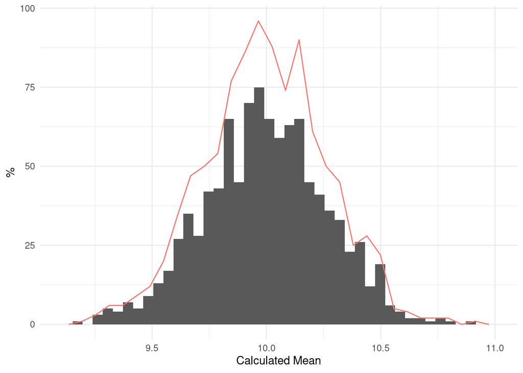

```r
means <- data.frame(means)  ## ggplot wants dataframes

 ggplot(data = means )+
   geom_histogram(bins=40, aes(x = means))+
   geom_freqpoly(aes(x = means, colour="red"), show.legend = F)+
   xlab("Calculated Mean")+
   ylab("%")+
   theme_minimal()
```

A basic R histogram plot.

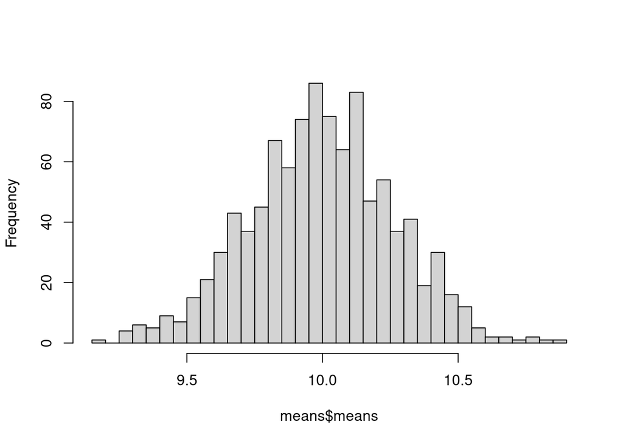

```r
 hist(means$means,
      breaks=40,
      main = paste(" "))
```

Standard Deviation with a **Magrittr pipe**

```r
means$means %>% sd()
```

```
## [1] 0.2668593
```

Standard Error of sample “sample”

```r
sd(sample)/sqrt(50)
```

```
## [1] 0.2838947
```

Another simulation, we used the rnorm function, and assumed a true population mean of μ= 10 and that σ= 2. But this time, we varied the sample size, from n= 2 to n= 500. For each simulation, we calculated both the mean, and the standard error

```r
set.seed(123)   # set a seed for reproducibility
means <- numeric(1000)
n <- numeric(1000)
se <- numeric(1000)
for (i in 1:1000){
  n[i] <- round(2+(i/2), digits=0)
  sample <- rnorm(n = n[i], mean = 10, sd = 2)
  means[i] <- mean(sample)
  se[i] <- sd(sample)/sqrt(n[i])
}
```

```r
meansdf <- data.frame(n,means,se)
```

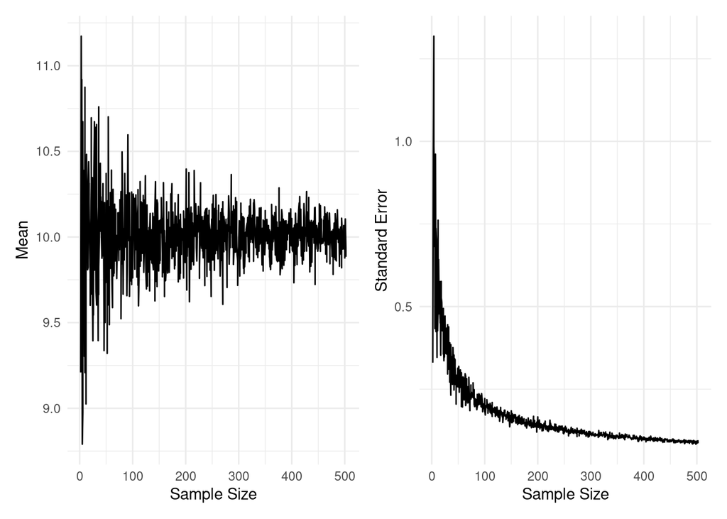

```r
p1 <- ggplot(data = meansdf )+
   geom_line(aes(x = n, y= means))+
   xlab("Sample Size")+
   ylab("Mean")+
  theme_minimal()

p2 <- ggplot(data = meansdf )+
  geom_line(aes(x = n, y= se))+
  xlab("Sample Size")+
  ylab("Standard Error")+
  theme_minimal()

p1 + p2
```

This increase in precision is represented by the standard error: with increasing sample size, the standard error becomes smaller and smaller.

We have now explored the quintessential elements we need to conduct a meta-analysis: an (1) observed effect size or outcome measure, and (2) its precision, expressed as the standard error. If these two types of information can be calculated from a published study, it is usually also possible to perform a meta-analytic synthesis.

## Effect Sizes in Single group design

## Means

Set seed of 123 for reproducibility and take a random sample (n=50).

```r
set.seed(123)
sample <- rnorm(n = 50, mean = 20, sd = 5)
```

Calculate the mean

```r
mean(sample)
```

```
## [1] 20.17202
```

Calculate the standard error

```r
sd(sample)/sqrt(50)
```

```
## [1] 0.6546889
```

## Proportions

We define the following values for k and n:

```r
k <- 25
n <- 125
```

Calculate the proportion

```r
p <- k/n
p
```

```
## [1] 0.2
```

Calculate the standard error

```r
sqrt((p*(1-p))/n)
```

```
## [1] 0.03577709
```

## Correlations

### Pearson Product-Moment Correlation

We can also calculate rxy and z directly in R, using the cor and log function.

Simulate two continuous variables x and y

```r
set.seed(12345)
x <- rnorm(20, 50, 10)
y <- rnorm(20, 10, 3)
```

Calculate the correlation between x and y

```r
r <- cor(x,y)
r
```

```
## [1] 0.2840509
```

Calculate Fisher’s z

```r
z <- 0.5*log((1+r)/(1-r))
z
```

```
## [1] 0.2920831
```

### Point-Biserial Correlation

In cases where only one variable y is continuous, while the other variable x is dichotomous (i.e. only takes two values), a point-biserial correlation can be calculated, which expresses how well y can be predicted from the group membership in x. The point-biserial correlation bears a close resemblance to the standardized mean difference Like the product-moment correlation, the point-biserial correlation has undesirable statistical properties for meta-analyses, such as range restriction when the group proportions are unequal  
When we are interested in group differences on a continuous outcome variable, it is therefore advised to convert point-biserial correlations to standardized mean differences for meta-analyses

## Effects sizes in control group designs

### Mean differences

#### Between-Group Mean Difference

In a real meta-analysis, the mean of x1 and x2 as well as their standard deviations s1 and s2 are something that we can hopefully extract from the published paper, same as the group sample sizes n1 and n2. So you do not have to worry about this first part too much.

```r
# Generate two random variables with different population means
set.seed(123)
x1 <- rnorm(n = 20, mean = 10, sd = 3)
x2 <- rnorm(n = 20, mean = 15, sd = 3)

# Calculate values we need for the formulas
s1 <- sd(x1)
s2 <- sd(x2)
n1 <- 20
n2 <- 20
```

we calculate the mean difference and its standard error

```r
# Calculate the mean difference
MD <- mean(x1) - mean(x2)
MD
```

```
## [1] -4.421357
```

```r
# Calculate s_pooled
s_pooled <- sqrt(
  (((n1-1)*s1^2) + ((n2-1)*s2^2))/
    ((n1-1)+(n2-1))
)

# Calculate the standard error
se <- s_pooled*sqrt((1/n1)+(1/n2))
se
```

```
## [1] 0.8577262
```

For a meta-analysis of mean differences, we only have to prepare the following columns in our data set:

- n.e. The number of observations in the intervention/experimental group.
- mean.e. The mean of the intervention/experimental group.
- sd.e. The standard deviation in the intervention/experimental group.
- n.c. The number of observations in the control group.
- mean.c. The mean of the control group.
- sd.c. The standard deviation in the control group.

#### Between-Group Standardized Mean Difference

It’s the difference in means between two independent groups, standardized by the pooled standard deviation spooled. In the literature, the standardized mean difference is also often called Cohen’s d.

It expresses the difference between two groups in units of standard deviations.

Standardized mean differences are much more often used in meta-analyses than unstandardized mean differences. This is because SMDbetween can be compared between studies, even if those studies did not measure the outcome of interest using the same instruments.

here are several functions in R which allow us to calculate SMDbetween/Cohen’s d in one step. Here, we use the esc_mean_sd function.

```r
# Load esc package
library(esc)

# Define the data we need to calculate SMD/d
# This is just some example data that we made up
grp1m <- 50   # mean of group 1
grp2m <- 60   # mean of group 2
grp1sd <- 10  # sd of group 1
grp2sd <- 10  # sd of group 2
grp1n <- 100  # n of group1
grp2n <- 100  # n of group2

# Calculate effect size
esc_mean_sd(grp1m = grp1m, grp2m = grp2m,
            grp1sd = grp1sd, grp2sd = grp2sd,
            grp1n = grp1n, grp2n = grp2n)
```

```
##
## Effect Size Calculation for Meta Analysis
##
##      Conversion: mean and sd to effect size d
##     Effect Size:  -1.0000
##  Standard Error:   0.1500
##        Variance:   0.0225
##        Lower CI:  -1.2940
##        Upper CI:  -0.7060
##          Weight:  44.4444
```

#### Within-Group (Standardized) Mean Difference

It can be calculated when a difference within one group is examined. This is usually the case when the same group of people is measured at two different time points (e.g. before an intervention and after an intervention).

(S)MDwithin is calculated using data that is not independent. For example, it is likely that the value of person i at measurement point t1 has influenced the value of the same person at measurement point t2. Due to the fact that within-group mean differences are usually based on data measured at different time points, they are also known as the (standardized) mean gain.

The within-group mean difference MDwithin is calculated the same way as MDbetween, except that we now compare the values of the same group at two different time points, t1 and t2.

Things become more complicated when we want to calculate a standardized version of the within-group mean difference.

An intuitive option is to standardize the mean difference **`MDwithin`** using the pooled standard deviation of both assessment points, st1 and st2.

An even better solution, proposed (among others) by Becker ([1988](https://bookdown.org/MathiasHarrer/Doing_Meta_Analysis_in_R/references.html#ref-becker1988synthesizing)), is to divide MDwithin by the standard deviation of the pre-test scores. The reason for this is that st1 is less likely to be influenced by intervention effects.

The standard errors of MDwithin and SMDwithin can be calculated using these formulas

$\begin{equation} SE_{\text{MD}_{\text{within}}}=\sqrt{\dfrac{s^2_{\text{t}_1}+s^2_{\text{t}_2}-(2r_{\text{t}_1\text{t}_2}s_{\text{t}_1}s_{\text{t}_2})}{n}} \end{equation}$

$\begin{equation} SE_{\text{SMD}_{\text{within}}} = \sqrt{\frac{2(1-r_{\text{t}_1\text{t}_2})}{n}+\frac{\text{SMD}^2_{\text{within}}}{2n}} \end{equation}$

The fact that we need two know the correlation $r_{\text{t}_1\text{t}_2}$ between the assessment points to calculate the standard error of within-group (standardized) mean differences is often problematic in practice.

The pre-post correlation of a variable is hardly ever reported in published research, which forces us to assume a value of $r_{\text{t}_1\text{t}_2}$ based on previous research.

It general, it should best be avoided to calculate within-group effect sizes for a meta-analysis ([Pim Cuijpers et al. 2017](https://bookdown.org/MathiasHarrer/Doing_Meta_Analysis_in_R/references.html#ref-cuijpers2017pre)). Especially when we have data from both an experimental **and** control group, it is much better to calculate the **between-group** (standardized) mean differences at t2 to measure the effect of a treatment, instead of pre-post comparisons.

Within-group mean difference may be calculated, however, when our meta-analysis focuses solely on studies which did not include a control group.

The within-group standardized mean difference (also known as the within-group Cohen’s d) can be calculated like this in *R*:

```r
# Define example data needed for effect size calculation
x1 <- 20    # mean at t1
x2 <- 30    # mean at t2
sd1 <- 13   # sd at t1
n <- 80     # sample size
r <- 0.5    # correlation between t1 and t2

# Caclulate the raw mean difference
md_within <- x2 - x1

# Calculate the smd:
# Here, we use the standard deviation at t1
# to standardize the mean difference
smd_within <- md_within/sd1
smd_within
```

```
## [1] 0.7692308
```

```r
# Calculate standard error
se_within <- sqrt(((2*(1-r))/n) +
              (smd_within^2/(2*n)))
se_within
```

```
## [1] 0.1272722
```

Meta-analyses of within-group (standardized) mean differences can only be performed in *R* using **pre-calculated effect sizes** . The following columns are required in our data set:

- **`TE`**: The calculated within-group effect size.
- **`seTE`**: The standard error of the within-group effect size.

Standardization, however, is not a **“Get Out of Jail Free card”**. The size of a particular study’s SMD depends heavily on the **variability** of its sample. In addition, we have also seen that the **unit** by which to standardize is often **less clearly defined** than one may think.

Of course, the best solutation would be if outcomes were **measured on the same scale in all studies**, so that **raw mean differences** could be used. In many research fields, however, we are living far away from such a level of methodological harmony. Thus, unfortunately, standardized effect sizes are often our **second best option**.

### Risk & Odds Ratios

#### Risk Ratio

Because both pEtreat and pEcontrol can only have values between 0 and 1, the RR has a few interesting properties. First of all, a risk ratio can never be negative. Secondly, if there is no difference between the treatment group and the control group, RR has a value of 1 (instead of 0, like SMDs). If an RR is larger than 1, this means that the treatment group increases the risk of event E; if RR is smaller than 1, the intervention reduces the risk.

A peculiarity of the RR is that same-sized effects are not **equidistant**. This means that risk ratios do not follow a normal distribution, which can be problematic in meta-analyses.

To avoid this issue, risk ratios are often transformed into the **log-risk ratio** before pooling. This ensures asymptotic normality, that effect sizes can assume any value, and that values are centered around 0 (meaning no effect). The transformation is performed by taking the natural logarithm of RR:

$$\begin{equation}
\log \text{RR} = \log_{e}(\text{RR})
\end{equation}$$

The standard error of the log-risk ratio can then be calculated using this formula:

$$\begin{equation}
SE_{\log \text{RR}} = \sqrt{\frac{1}{a}+\frac{1}{c} - \frac{1}{a+b} -
\frac{1}{c+d}}
\end{equation}$$

We can calculate the (log-)risk ratio in *R* like this:

```r
# Define data
a <- 46         # events in the treatment group
c <- 77         # events in the control group
n_treat <- 248  # sample size treatment group
n_contr <- 251  # sample size control group

# Calculate the risks
p_treat <- a/n_treat
p_contr <- c/n_contr

# Calculate the risk ratio
rr <- p_treat/p_contr
rr
```

```
## [1] 0.6046292
```

```r
# Calculate the log-risk ratio and its standard error
log_rr <- log(rr)
log_rr
```

```
## [1] -0.5031398
```

```r
se_log_rr <- sqrt((1/a) + (1/c) - (1/n_treat) - (1/n_contr))
se_log_rr
```

```
## [1] 0.1634314
```

The calculation of risk ratios becomes difficult when there are **zero cells**. It is possible in practice that a or c (or both) are zero, meaning that no event was recorded in the treatment or control group.

This issue is often dealt with using a **continuity correction**. The most common continuity correction method is to add an increment of 0.5 in all cells that are zero ([Gart and Zweifel 1967](https://bookdown.org/MathiasHarrer/Doing_Meta_Analysis_in_R/references.html#ref-gart1967bias)).

However, there is evidence that such corrections can lead to biased results ([Efthimiou 2018](https://bookdown.org/MathiasHarrer/Doing_Meta_Analysis_in_R/references.html#ref-efthimiou2018practical)).

A special form of the **zero cell** problem are **double-zero studies**. These are studies in which both a and c are zero. Intuitively, one might think that the results of such studies simply mean that the risk in the intervention and control group are similar, and that RR = 1.

Unfortunately, it is not that easy. It is very much possible that there is a true effect between the two groups, but that the sample size was too small to detect this difference. This is particularly likely when the probability that E occurs is very low.

For this reason, double-zero studies are often discarded completely when pooling the effects.

This leads us to one last caveat pertaining to risk ratios: they give us no information on *how common an event is **in general***. If a meta-analysis reports a risk ratio of 0.5, for example, we know that an intervention reduced the risk by half. But we do not know if it reduced the risk from 40% to 20%, or from 0.004% to 0.002%.

When we conduct a meta-analysis in *R*, it is usually not necessary to calculate the log-risk ratio of a study by hand. We also do not have to worry about zero cells when importing the data. The following columns should be included in our data set:

- **`event.e`**. The number of events in the treatment or experimental group.
- **`n.e`**. The sample size of the treatment or experimental group.
- **`event.c`**. The number of events in the control group.
- **`n.c`**. The sample size of the control group.

#### Odds Ratio

OR describes the ratio of events to non-events, not the **probability** of the event.

Like the risk ratio, the odds ratio as such has undesirable statistical properties for meta-analyses. It is therefore also common to transform the odds ratio to the **log-odds ratio** using the natural logarithm:

$$\begin{equation}
\log \text{OR} = \log_{e}(\text{OR})
\end{equation}$$

The standard error of the log-odds ratio can be calculated using this formula:

$$\begin{equation}
SE_{\log \text{OR}} =
\sqrt{\frac{1}{a}+\frac{1}{b}+\frac{1}{c}+\frac{1}{d}}
\end{equation}$$

The `esc_2x2` function in the **{esc}** package provides an easy way to calculate the (log) odds ratio in *R*.

```r
library(esc)

# Define data
grp1yes <- 45  # events in the treatment group
grp1no <- 98   # non-events in the treatment group
grp2yes <- 67  # events in the control group
grp2no <- 76   # non-events in the control group

# Calculate OR by setting es.type to "or"
esc_2x2(grp1yes = grp1yes, grp1no = grp1no,
        grp2yes = grp2yes, grp2no = grp2no,
        es.type = "or")
```

```
##
## Effect Size Calculation for Meta Analysis
##
##      Conversion: 2x2 table (OR) coefficient to effect size odds ratio
##     Effect Size:   0.5209
##  Standard Error:   0.2460
##        Variance:   0.0605
##        Lower CI:   0.3216
##        Upper CI:   0.8435
##          Weight:  16.5263
```

```r
# Calculate logOR by setting es.type to "logit"
esc_2x2(grp1yes = grp1yes, grp1no = grp1no,
              grp2yes = grp2yes, grp2no = grp2no,
              es.type = "logit")
```

```
##
## Effect Size Calculation for Meta Analysis
##
##      Conversion: 2x2 table (OR) to effect size logits
##     Effect Size:  -0.6523
##  Standard Error:   0.2460
##        Variance:   0.0605
##        Lower CI:  -1.1344
##        Upper CI:  -0.1701
##          Weight:  16.5263
```

The same problems pertaining to risk ratios, **zero cells** and **double-zero studies** are also relevant when calculating odds ratios. However, the odds ratio has one additional disadvantage compared to RRs: many people find it harder to understand, and ORs are often erroneously interpreted as RRs.

It is, therefore, often preferable to either only use risk ratios in a meta-analysis, or to convert odds ratios to risk ratios when reporting the results ([Julian Higgins et al. 2019, chap. 6.4.1.2](https://bookdown.org/MathiasHarrer/Doing_Meta_Analysis_in_R/references.html#ref-higgins2019cochrane)). The conversion can be performed using this formula ([Zhang and Yu 1998](https://bookdown.org/MathiasHarrer/Doing_Meta_Analysis_in_R/references.html#ref-zhang1998whats)):

$$\begin{equation}
\text{RR} =
\frac{\text{OR}}{\left(1-\dfrac{c}{n_{\text{control}}}\right)+
\left(\dfrac{c}{n_{\text{control}}}\times \text{OR} \right)}
\end{equation}$$

To conduct a meta-analysis of odds ratios in *R*, the following columns should be included in our data set:

- **`event.e`**. The number of events in the treatment or experimental group.
- **`n.e`**. The sample size of the treatment or experimental group.
- **`event.c`**. The number of events in the control group.
- **`n.c`**. The sample size of the control group.

### Incidence Rate Ratios

To incorporate time into our effect size estimate, we can calculate **incidence rate ratios**, which are sometimes simply called **rate ratios**. Incidence rate ratios consist of two **incidence rates**. To calculate these incidence rates, we have to first understand the concept of **person-time**.

We can then calculate the incidence rate IR using this formula

$$\begin{equation}
\text{IR} = \frac{E}{T}
\end{equation}$$

where *E* = number of events, *T* = person-time.

Let’s suppose our IR is 4/40=0.1. This incidence rate means that, if we would follow 1000 people for one year, 100 would experience the event during that time.

To calculate the incidence rate ratio IRR, we have to divide the incidence rate of one group by the incidence rate of another group:

$$\begin{equation}
\text{IRR} = \frac{ E_{\text{treat}}/T_{\text{treat}}
}{E_{\text{control}}/T_{\text{control}}}
\end{equation}$$

The IRR shares many properties with the risk and odds ratio, such as being centered at 1 and always being non-negative. Like ORs and RRs, incidence rate ratios are also often log-transformed for meta-analyses, creating the log-incidence rate ratio:

$$\begin{equation}
\log \text{IRR} = \log_{e}(\text{IRR})
\end{equation}$$

For which we can calculate the standard error like this:

$$\begin{equation}
SE_{\log \text{IRR}} =
\sqrt{\frac{1}{E_{\text{treat}}}+\frac{1}{E_{\text{control}}}}
\end{equation}$$

We can calculate the (log-)incidence ratio and the standard error in *R* like this:

```r
# Define Data
e_treat <- 28    # Number of events in the treatment group
e_contr <- 28    # Number of events in the control group
t_treat <- 3025  # Person-time in the treatment group
t_contr <- 2380  # Person-time in the control group

# Calculate IRR
irr <- (e_treat/t_treat)/(e_contr/t_contr)
irr
```

```
## [1] 0.7867769
```

```r
# Calculate log-IRR
log_irr <- log(irr)

# Calculate standard error
se_log_irr <- sqrt((1/e_treat)+(1/e_contr))
```

In this example, we simulated a case in which the number of events Etreat and Econtrol is exactly equal, but where the treatment group has a longer person-time at risk.

Therefore, the result we get is not 1, but IRR ≈ 0.79, indicating that the incidence rate is smaller in the treatment group.

There is one caveat we should consider when calculating IRRs as part of a meta-analysis: it is important that the incidence data reported in the included articles is fine-grained enough. Sometimes, papers only report the total number of events during the entire study period and not the number of events recorded at each assessment point in between. It is also possible that no interim assessments were made to begin with.

Our **estimate of the person-time** will be best if the time between assessment points is as small as possible. If assessment intervals in a study are too coarse depends on the context of the meta-analysis, but it is always advisable to conduct **sensitivity analyses** ([Panageas et al. 2007](https://bookdown.org/MathiasHarrer/Doing_Meta_Analysis_in_R/references.html#ref-panageas2007you)).

This means to recalculate the IRR of studies based on different estimates of the person-time:

- using the **midpoint** of the interval,
- using the **last “event-free” assessment point**, and
- using the assessment point in which the event was **detected**.

If the results of all three of these meta-analyses point in the same direction, we can be more confident in our findings. We should also make sure that the assessment periods do not differ too much between studies (e.g. one study examining events daily, and the other only each year).

When there are doubts about the applicability of IRRs for a meta-analysis, there is always the possibility to **calculate risk or odds ratios** *instead* (or *in addition*). However, when we do this, we should make sure that the assessment point was similar in each study (e.g. after one year).

To calculate a meta-analysis based on incidence rate ratios in *R*, the following columns need to be prepared in our data set:

- **`event.e`**: The total number of events in the treatment or experimental group.
- **`time.e`**: The person-time in the treatment or experimental group. The person-time has to be expressed in the same units (person-days, person-weeks, or person-years) in all studies.
- **`event.c`**: The total number of events in the control group.

**`- time.c`**: The person-time in the control group. The person-time has to be expressed in the same units (person-days, person-weeks, or person-years) in all studies.

*N.B.* To calculate an incidence rate, we assume that the **underlying risk** in a population is **constant** over time (e.g. between year 1 and year 2 of a study). For IRRs it is assumed that, while the underlying risk may differ between the treatment and control group (e.g. because the treatment reduces the risk of experiencing an event), the risk **within** each group is constant.

This assumption is quite simplistic.

Using IRRs is only adequate when the average **observation periods** of both groups do **not differ** substantially, and when the **baseline risk** of the studied event is rather **low** (<25%).

An alternative, and often preferable measure to express group differences based on time-to-event data are **hazard ratios** (HR). A hazard ratio is a ratio of two (proportional) **hazard functions**. Such hazard functions describe the (varying) instantaneous risk (i.e., the “hazard”) of experiencing an event at some timepoint t, provided that a person has not yet experienced this event until t. –> *i.e. “Azzardo Istantaneo”.*

Hazard ratios are typically estimated based on individual participant data using **Cox regression** models. If we can extract the log-hazard ratio $\log_{\text{e}}(\text{HR})$ and its corresponding standard error from all studies, it is possible to perform a meta-analysis using **inverse-variance pooling!!**

This works in the same way as one would pool, say, log-risk or odds ratios. In *R*, log-hazard ratios can be pooled using the `metagen` function, with the `sm` argument set to `"HR"`.

## Effect Size Correction

Come già detto, l’effect size **stimato** $\hat\theta_k$ devia dall’effect size **reale** $\hat\theta$ di una misura pari all’errore di campionamento $\epsilon_k$. Ma non solo.

Anche per $\epsilon_k$ tendente a 0, la stima della dimensione dell’effetto $\hat\theta_k$ può essere gravata da errori sistematici, **bias**. I Bias possono avere origini differenti. Alcuni sono causati dalla proprietà matematiche delle metriche dell’effect size. Altri sono generati dal modo in cui viene condotto lo studio.  
I bias legati alla conduzione dello studio possono essere gestititi valutando il **risk of bias** dello studio. Questo giudizio può quindi essere usato per determinare se il risk of bias è associato a differenze negli effetti aggregati (**pooled effects**), per esempio nelle analisi per sottogruppo.

Per gestire le distorsioni (bias) che provengono dalle proprietà della metrica della dimensione d’effetto, possiamo usare specifici metodi di **effect size correction** per adattare i dati prima di cominciare la meta-analisi.

### Small Sample Bias

Per esempio nel caso della SMD (standardized mean difference). Si tratta di un effect size che sistematicamente sovrastima il true effect size quando il total sample size è piccolo – caso che purtroppo è frequente nella realtà.

È quindi sensato correggere le differenze medie standardizzate di tutti gli studi inclusi con small sample bias; viene prodotta una effect size chiamata *g* di **Hedges**. La formula per convertire *SMD/Cohen* $d$ in *SMD/Hedges* $g$ è:

$$\begin{equation}
g = \text{SMD} \times (1-\frac{3}{4n-9})
\end{equation}$$

In questa formula, $n$ rappresenta il total sample size dello studio. Possiamo converire la SMDs/Cohen $d$ ad Hedges’ $g$ usando la funzione `hedges_g` del package **{esc}**.

```r
# Load esc package
#library(esc)

# Define uncorrected SMD and sample size n
SMD <- 0.5
n <- 30

# Convert to Hedges g
g <- hedges_g(SMD, n)
g
```

```
## [1] 0.4864865
```

```r
set.seed(123)   # setto un seed
n <- numeric(100)
g <- numeric(100)

for (i in 1:100){  # sample size da 1 a 100
  n[i] <- i
  g[i] <- hedges_g(0.2, i) # SMD 0.2 -> g
}
```

```r
hedgesdf <- data.frame(n,g)

head(hedgesdf)
```

```
##   n         g
## 1 1 0.3200000
## 2 2 0.8000000
## 3 3 0.0000000
## 4 4 0.1142857
## 5 5 0.1454545
## 6 6 0.1600000
```

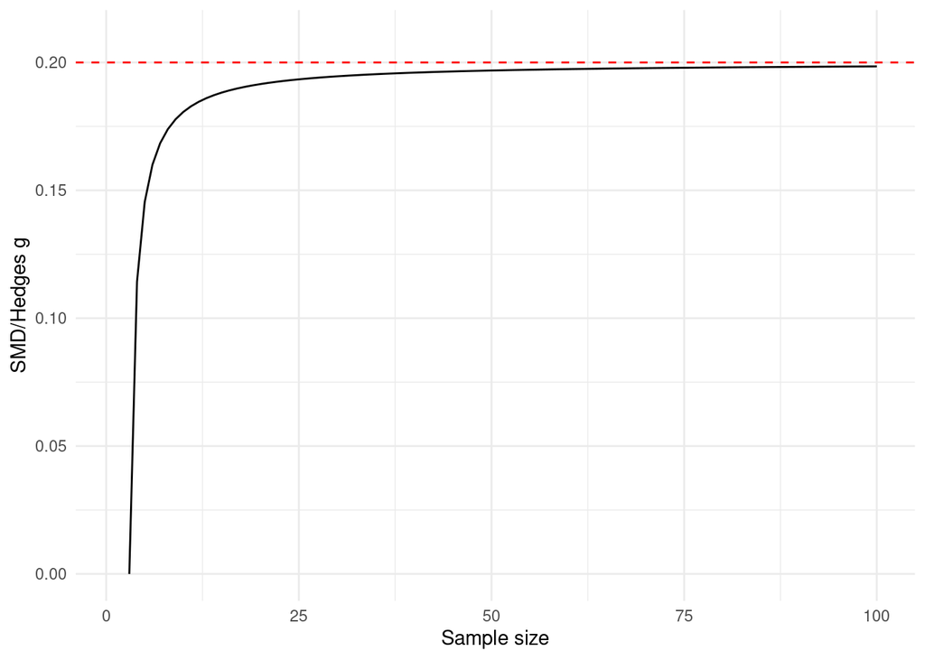

```r
ggplot(hedgesdf)+
  geom_line(aes(x=n, y=g))+
  xlab("Sample size")+
  ylab("SMD/Hedges g")+
  ylim(0,.21)+
  geom_hline(yintercept=0.20, linetype="dashed", color = "red")+
             theme_minimal()
```

Da notare che in alcuni casi SMD e $g$ si Hedges vengono utilizzati in maniera intercambiabile, per cui è rilevante controllare che gli autori si riferiscano invece alla SMD non controllata, oppure che abbiano corretto per small sample bias.

### Unreliability - Inaffidabilità

E’ possibile corregere per l’attenuazione se abbiamo a disposizione una stima della (un-)reliability, e quindi ottenere una migliore stima dell’effect size.

Questa correzione rientra nelle cosiddette “tecniche di Hunter e Schmidt”.

La correzione per l’attenuazione di Hunter e Schimdt può essere applicata alle (product-moment) correlations e alle standardized mean differences.  
La **corrected version** della correlazione ${r_{xy}}_{c}$ si calcola con:

$$\begin{equation}
{r_{xy}}_{c} = \frac{r_{xy}}{\sqrt{r_{xx}}}
\end{equation}$$

dove ${r_{xx}}$ è la stima della reliability (test-restest).

Quindi, se il nostro effect size è la standardized mean difference fra due gruppi, in cui viene misurato un outcome $x$, la forma corretta per l’attenuzione $SMD_c$ sarà:

$$\begin{equation}
\text{SMD}_c = \frac{\text{SMD}}{\sqrt{r_{xx}}}
\end{equation}$$

Se invece il nostro effect size è una product-moment correlation tra due variabili $x$ ed $y$, è possibile correggere per la unreliability di entrambe , premesso che si conosca anche ${r_{yy}}$, la reliability del coefficiente $y$ :

$$\begin{equation}
{r_{xy}}_{c} = \frac{r_{xy}}{\sqrt{r_{xx}}\sqrt{r_{yy}}}
\end{equation}$$

Infine, dobbiamo correggere lo standard error. Lo standard error si corregge nello stesso modo in cui correggiamo l’effect size stesso. Se vogliamo correggere la sola variabile $x$, usiamo la formula:

$$\begin{equation}
SE_c = \frac{SE}{\sqrt{r_{xx}}}
\end{equation}$$

Se vogliamo correggere per $x$ ed $y$ (product-moment correlation) usiamo la formula:

$$\begin{equation}
SE_c = \frac{SE}{\sqrt{r_{xx}}\sqrt{r_{yy}}}
\end{equation}$$

Dopo la correzione di SMD o della correlazione, è possibile applicare altre trasformazioni comuni, come convertire ${r_{xy}}_{c}$ nella $z$ di Fischer o $SMDc$ nella $g$ di Hedges.

Un esempio in *R*:

```r
# definisco uncorrected correlation e SMD con i loro standard error
r_xy <- 0.34
se_r_xy <- 0.09
smd <- 0.65
se_smd <- 0.18

# Ddefinisco le relaibilty di x e y
r_xx <- 0.8
r_yy <- 0.7

# Correggo SMD per la unreliability di x
smd_c <- smd/sqrt(r_xx)
smd_c
```

```
## [1] 0.7267221
```

```r
se_c <- se_smd/sqrt(r_xx)
se_c
```

```
## [1] 0.2012461
```

```r
# Correggo correlation per unreliability di x e y
r_xy_c <- r_xy/(sqrt(r_xx)*sqrt(r_yy))
r_xy_c
```

```
## [1] 0.4543441
```

```r
se_c <- se_r_xy/(sqrt(r_xx)*sqrt(r_yy))
se_c
```

```
## [1] 0.1202676
```

In questi risultati, è evidente che a causa della correzione, la correlazione e l’SMD sono maggiori del valore iniziale non corretto. Tuttavia, vediamo che anche gli errori standard aumentano. Questo risultato è voluto; correggiamo l’errore standard in modo che incorpori anche l’errore di misurazione che assumiamo per i nostri dati.